# Guns in the United States

> - NCIS Background Checks
> - Data Wrangling
> - Exploratory Analysis
> - Research Limitations
> - Conclusions

## NCIS Background Checks

Since November, 1998, the FBI has required by the Brady Handgun Violence Prevention Act of 1993 that Federal Firearm Licensees run background checks in order to determine eligibility of prospective buyers to purchase firearms or explosives. Cashiers at firearm vendors must initiate checks with the FBI determining that their customers do not have criminal records before a sale is completed. Since the implementation of this system (the National Instant Criminal Background Check System or NCIS) researchers have used the number of background checks as a proxy for total gun purchases during a given period of time. Although a one-to-one correlation between a gun background check and a sale cannot be made, using background checks is still the most widely accepted method for firearm sales estimation.

> In this report, we will look at United States data released by the FBI with the numbers of differing types of firearm background checks made for each state by month and year since 1998. We will use Python to first investigate this data and estimate gun sales; then, we will compare it with Census data gathered from 2010-2016.

**Imports**: The code below contains the imports necessary to gain access to libraries which make data investigation and visualization easier.

```python
%matplotlib inline
import pandas as pd
import matplotlib.pyplot as plt
import numpy as np
import seaborn as sb
import datetime
import pprint
```

## Data Wrangling

> We will begin to look at the data starting with the NCIS background check data, taken from gun_data.csv.

> **Note**: There will be short notes along the way describing what is going on in the code cells either above or below them, so if you don't see an explanation at first, please keep scrolling!

### Handling the Gun Data:

```python
check_data = pd.read_csv('ncis-and-census-data/gun_data.csv')
check_data.head()
```

|  | month | state | permit | permit_recheck | handgun | long_gun | other | multiple | admin | prepawn_handgun | ... | returned_other | rentals_handgun | rentals_long_gun | private_sale_handgun | private_sale_long_gun | private_sale_other | return_to_seller_handgun | return_to_seller_long_gun | return_to_seller_other | totals |
| --- | --- | --- | --- | --- | --- | --- | --- | --- | --- | --- | --- | --- | --- | --- | --- | --- | --- | --- | --- | --- | --- |
| 0 | 2017-09 | Alabama | 16717.0 | 0.0 | 5734.0 | 6320.0 | 221.0 | 317 | 0.0 | 15.0 | ... | 0.0 | 0.0 | 0.0 | 9.0 | 16.0 | 3.0 | 0.0 | 0.0 | 3.0 | 32019 |
| 1 | 2017-09 | Alaska | 209.0 | 2.0 | 2320.0 | 2930.0 | 219.0 | 160 | 0.0 | 5.0 | ... | 0.0 | 0.0 | 0.0 | 17.0 | 24.0 | 1.0 | 0.0 | 0.0 | 0.0 | 6303 |
| 2 | 2017-09 | Arizona | 5069.0 | 382.0 | 11063.0 | 7946.0 | 920.0 | 631 | 0.0 | 13.0 | ... | 0.0 | 0.0 | 0.0 | 38.0 | 12.0 | 2.0 | 0.0 | 0.0 | 0.0 | 28394 |
| 3 | 2017-09 | Arkansas | 2935.0 | 632.0 | 4347.0 | 6063.0 | 165.0 | 366 | 51.0 | 12.0 | ... | 0.0 | 0.0 | 0.0 | 13.0 | 23.0 | 0.0 | 0.0 | 2.0 | 1.0 | 17747 |
| 4 | 2017-09 | California | 57839.0 | 0.0 | 37165.0 | 24581.0 | 2984.0 | 0 | 0.0 | 0.0 | ... | 0.0 | 0.0 | 0.0 | 0.0 | 0.0 | 0.0 | 0.0 | 0.0 | 0.0 | 123506 |

5 rows × 27 columns

**DataFrame Creation**: Above, we have the first few rows of a pandas DataFrame containing the data in the gun_data csv file.

> We don't need all of these columns however. In order to estimate gun sales, we will use a method designed by Jurgen Brauer, a professor at Georgia Regents University, who developed his method after interviewing gun shop owners. Each long gun and handgun check is counted as 1.1 sales while each multiple-gun check is counted as two sales; other types of checks are omitted. So, we can eliminate most of the 27 columns to get the necessary data.

```python
fields = ['month', 'state', 'permit', 'handgun', 'long_gun', 'multiple', 'totals']
check_data = pd.read_csv('ncis-and-census-data/gun_data.csv', usecols=fields)
check_data.head()
```

|  | month | state | permit | handgun | long_gun | multiple | totals |
| --- | --- | --- | --- | --- | --- | --- | --- |
| 0 | 2017-09 | Alabama | 16717.0 | 5734.0 | 6320.0 | 317 | 32019 |
| 1 | 2017-09 | Alaska | 209.0 | 2320.0 | 2930.0 | 160 | 6303 |
| 2 | 2017-09 | Arizona | 5069.0 | 11063.0 | 7946.0 | 631 | 28394 |
| 3 | 2017-09 | Arkansas | 2935.0 | 4347.0 | 6063.0 | 366 | 17747 |
| 4 | 2017-09 | California | 57839.0 | 37165.0 | 24581.0 | 0 | 123506 |

The above, simpler DataFrame looks better for this investigation.

```python
check_data['sales_checks'] = ((check_data.handgun + check_data.long_gun)*1.1) + (check_data.multiple*2)
check_data.head()
```

|  | month | state | permit | handgun | long_gun | multiple | totals | sales_checks |
| --- | --- | --- | --- | --- | --- | --- | --- | --- |
| 0 | 2017-09 | Alabama | 16717.0 | 5734.0 | 6320.0 | 317 | 32019 | 13893.4 |
| 1 | 2017-09 | Alaska | 209.0 | 2320.0 | 2930.0 | 160 | 6303 | 6095.0 |
| 2 | 2017-09 | Arizona | 5069.0 | 11063.0 | 7946.0 | 631 | 28394 | 22171.9 |
| 3 | 2017-09 | Arkansas | 2935.0 | 4347.0 | 6063.0 | 366 | 17747 | 12183.0 |
| 4 | 2017-09 | California | 57839.0 | 37165.0 | 24581.0 | 0 | 123506 | 67920.6 |

Here, we have added a column, sales_checks (estimated sales from background checks), which is calculated using Jurgen Brauer's method of estimating sales, mentioned earlier; we will use this column for analysis of estimated firearm sales. But first, more can be done to make the data easier to work with.

```python
#new date dataframe with year and month split up
dates = pd.DataFrame(check_data.month.str.split('-',1).tolist(), columns = ['year','month'])
check_data = check_data.drop('month', axis=1)
```

```python
#create new dataframe merging date dataframe with original
clean_check_data = pd.concat([check_data,dates], axis=1)
#reset order of columns
clean_check_data = clean_check_data[['month','year','state','permit', 'handgun', 'long_gun', 'multiple', 'sales_checks', 'totals']]
clean_check_data.head()
```

|  | month | year | state | permit | handgun | long_gun | multiple | sales_checks | totals |
| --- | --- | --- | --- | --- | --- | --- | --- | --- | --- |
| 0 | 09 | 2017 | Alabama | 16717.0 | 5734.0 | 6320.0 | 317 | 13893.4 | 32019 |
| 1 | 09 | 2017 | Alaska | 209.0 | 2320.0 | 2930.0 | 160 | 6095.0 | 6303 |
| 2 | 09 | 2017 | Arizona | 5069.0 | 11063.0 | 7946.0 | 631 | 22171.9 | 28394 |
| 3 | 09 | 2017 | Arkansas | 2935.0 | 4347.0 | 6063.0 | 366 | 12183.0 | 17747 |
| 4 | 09 | 2017 | California | 57839.0 | 37165.0 | 24581.0 | 0 | 67920.6 | 123506 |

```python
#convert years to integers
clean_check_data['year'] = clean_check_data['year'].astype(int)
```

```python
#switch index to state
clean_check_data = clean_check_data.set_index('state')
clean_check_data.head()
```

| state | month | year | permit | handgun | long_gun | multiple | sales_checks | totals |
| --- | --- | --- | --- | --- | --- | --- | --- | --- |
| Alabama | 09 | 2017 | 16717.0 | 5734.0 | 6320.0 | 317 | 13893.4 | 32019 |
| Alaska | 09 | 2017 | 209.0 | 2320.0 | 2930.0 | 160 | 6095.0 | 6303 |
| Arizona | 09 | 2017 | 5069.0 | 11063.0 | 7946.0 | 631 | 22171.9 | 28394 |
| Arkansas | 09 | 2017 | 2935.0 | 4347.0 | 6063.0 | 366 | 12183.0 | 17747 |
| California | 09 | 2017 | 57839.0 | 37165.0 | 24581.0 | 0 | 67920.6 | 123506 |

After splitting the date column into separate month and year columns, setting the year column to integer type, and setting the index of the DataFrame to have states as row names, the gun data is now ready for further investigation.

### Handling the Census data:

```python
census_data = pd.read_csv('ncis-and-census-data/census_data.csv')
census_data.head()
```

|  | Fact | Fact Note | Alabama | Alaska | Arizona | Arkansas | California | Colorado | Connecticut | Delaware | ... | South Dakota | Tennessee | Texas | Utah | Vermont | Virginia | Washington | West Virginia | Wisconsin | Wyoming |
| --- | --- | --- | --- | --- | --- | --- | --- | --- | --- | --- | --- | --- | --- | --- | --- | --- | --- | --- | --- | --- | --- |
| 0 | Population estimates, July 1, 2016, (V2016) | NaN | 4,863,300 | 741,894 | 6,931,071 | 2,988,248 | 39,250,017 | 5,540,545 | 3,576,452 | 952,065 | ... | 865454 | 6651194 | 27,862,596 | 3,051,217 | 624,594 | 8,411,808 | 7,288,000 | 1,831,102 | 5,778,708 | 585,501 |
| 1 | Population estimates base, April 1, 2010, (V2... | NaN | 4,780,131 | 710,249 | 6,392,301 | 2,916,025 | 37,254,522 | 5,029,324 | 3,574,114 | 897,936 | ... | 814195 | 6346298 | 25,146,100 | 2,763,888 | 625,741 | 8,001,041 | 6,724,545 | 1,853,011 | 5,687,289 | 563,767 |
| 2 | Population, percent change - April 1, 2010 (es... | NaN | 1.70% | 4.50% | 8.40% | 2.50% | 5.40% | 10.20% | 0.10% | 6.00% | ... | 0.063 | 0.048 | 10.80% | 10.40% | -0.20% | 5.10% | 8.40% | -1.20% | 1.60% | 3.90% |
| 3 | Population, Census, April 1, 2010 | NaN | 4,779,736 | 710,231 | 6,392,017 | 2,915,918 | 37,253,956 | 5,029,196 | 3,574,097 | 897,934 | ... | 814180 | 6346105 | 25,145,561 | 2,763,885 | 625,741 | 8,001,024 | 6,724,540 | 1,852,994 | 5,686,986 | 563,626 |
| 4 | Persons under 5 years, percent, July 1, 2016, ... | NaN | 6.00% | 7.30% | 6.30% | 6.40% | 6.30% | 6.10% | 5.20% | 5.80% | ... | 0.071 | 0.061 | 7.20% | 8.30% | 4.90% | 6.10% | 6.20% | 5.50% | 5.80% | 6.50% |

5 rows × 52 columns

**DataFrame Creation**: Above, we have the first few rows of a pandas DataFrame containing the data in the census_data csv file.

> We don't need all of the statistics in the Census data however. For the purposes of this investigation, we will exclude all statistics except population estimates for 2010 and 2016, and population density (pop. per square mile).

```python
#select indexes of wanted statistics
pop_est_2016 = census_data.loc[[0]]
pop_est_2010 = census_data.loc[[1]]
pop_sq_mile = census_data.loc[[62]]
new_data = pd.concat([pop_est_2016, pop_est_2010, pop_sq_mile])
new_data = new_data.drop('Fact Note', axis=1)
new_data.head(6)
```

|  | Fact | Alabama | Alaska | Arizona | Arkansas | California | Colorado | Connecticut | Delaware | Florida | ... | South Dakota | Tennessee | Texas | Utah | Vermont | Virginia | Washington | West Virginia | Wisconsin | Wyoming |
| --- | --- | --- | --- | --- | --- | --- | --- | --- | --- | --- | --- | --- | --- | --- | --- | --- | --- | --- | --- | --- | --- |
| 0 | Population estimates, July 1, 2016, (V2016) | 4,863,300 | 741,894 | 6,931,071 | 2,988,248 | 39,250,017 | 5,540,545 | 3,576,452 | 952,065 | 20,612,439 | ... | 865454 | 6651194 | 27,862,596 | 3,051,217 | 624,594 | 8,411,808 | 7,288,000 | 1,831,102 | 5,778,708 | 585,501 |
| 1 | Population estimates base, April 1, 2010, (V2... | 4,780,131 | 710,249 | 6,392,301 | 2,916,025 | 37,254,522 | 5,029,324 | 3,574,114 | 897,936 | 18,804,592 | ... | 814195 | 6346298 | 25,146,100 | 2,763,888 | 625,741 | 8,001,041 | 6,724,545 | 1,853,011 | 5,687,289 | 563,767 |
| 62 | Population per square mile, 2010 | 94.4 | 1.2 | 56.3 | 56 | 239.1 | 48.5 | 738.1 | 460.8 | 350.6 | ... | 10.7 | 153.9 | 96.3 | 33.6 | 67.9 | 202.6 | 101.2 | 77.1 | 105 | 5.8 |

3 rows × 51 columns

```python
#switch columns and rows
row1_to_col = pd.DataFrame(new_data.loc[0])
row2_to_col = pd.DataFrame(new_data.loc[1])
row3_to_col = pd.DataFrame(new_data.loc[62])
clean_census_data = pd.concat([row1_to_col, row2_to_col, row3_to_col], axis=1)
clean_census_data.head()
```

|  | 0 | 1 | 62 |
| --- | --- | --- | --- |
| Fact | Population estimates, July 1, 2016, (V2016) | Population estimates base, April 1, 2010, (V2... | Population per square mile, 2010 |
| Alabama | 4,863,300 | 4,780,131 | 94.4 |
| Alaska | 741,894 | 710,249 | 1.2 |
| Arizona | 6,931,071 | 6,392,301 | 56.3 |
| Arkansas | 2,988,248 | 2,916,025 | 56 |

```python
#set column headers
clean_census_data.columns = ['Population Estimate 2016', 'Population Estimate 2010', 'Population per Square Mile']
clean_census_data.head()
```

|  | Population Estimate 2016 | Population Estimate 2010 | Population per Square Mile |
| --- | --- | --- | --- |
| Fact | Population estimates, July 1, 2016, (V2016) | Population estimates base, April 1, 2010, (V2... | Population per square mile, 2010 |
| Alabama | 4,863,300 | 4,780,131 | 94.4 |
| Alaska | 741,894 | 710,249 | 1.2 |
| Arizona | 6,931,071 | 6,392,301 | 56.3 |
| Arkansas | 2,988,248 | 2,916,025 | 56 |

Above, we switch columns and rows so that the index of the DataFrame is **state**. This will make it easier to compare this data with the gun data as the indices will be the same. We have also set the column headers for a cleaner appearance and also for easier access to the columns later.

> In the code cell below, we will remove the 'Fact' row (now unnecessary) and take a look at the whole census DataFrame.

```python
clean_census_data = clean_census_data.drop('Fact')
clean_census_data
```

|  | Population Estimate 2016 | Population Estimate 2010 | Population per Square Mile |
| --- | --- | --- | --- |
| Alabama | 4,863,300 | 4,780,131 | 94.4 |
| Alaska | 741,894 | 710,249 | 1.2 |
| Arizona | 6,931,071 | 6,392,301 | 56.3 |
| Arkansas | 2,988,248 | 2,916,025 | 56 |
| California | 39,250,017 | 37,254,522 | 239.1 |
| Colorado | 5,540,545 | 5,029,324 | 48.5 |
| Connecticut | 3,576,452 | 3,574,114 | 738.1 |
| Delaware | 952,065 | 897,936 | 460.8 |
| Florida | 20,612,439 | 18,804,592 | 350.6 |
| Georgia | 10,310,371 | 9,688,680 | 168.4 |
| Hawaii | 1,428,557 | 1,360,301 | 211.8 |
| Idaho | 1,683,140 | 1,567,650 | 19 |
| Illinois | 12,801,539 | 12,831,574 | 231.1 |
| Indiana | 6,633,053 | 6,484,136 | 181 |
| Iowa | 3,134,693 | 3,046,869 | 54.5 |
| Kansas | 2,907,289 | 2,853,129 | 34.9 |
| Kentucky | 4,436,974 | 4,339,344 | 109.9 |
| Louisiana | 4,681,666 | 4,533,479 | 104.9 |
| Maine | 1,331,479 | 1,328,364 | 43.1 |
| Maryland | 6,016,447 | 5,773,786 | 594.8 |
| Massachusetts | 6,811,779 | 6,547,813 | 839.4 |
| Michigan | 9,928,300 | 9,884,129 | 174.8 |
| Minnesota | 5,519,952 | 5,303,924 | 66.6 |
| Mississippi | 2,988,726 | 2,968,103 | 63.2 |
| Missouri | 6,093,000 | 5,988,928 | 87.1 |
| Montana | 1,042,520 | 989,414 | 6.8 |
| Nebraska | 1,907,116 | 1,826,334 | 23.8 |
| Nevada | 2,940,058 | 2,700,691 | 24.6 |
| New Hampshire | 1,334,795 | 1,316,461 | 147 |
| New Jersey | 8,944,469 | 8,791,953 | 1,195.50 |
| New Mexico | 2081015 | 2059198 | 17 |
| New York | 19745289 | 19378110 | 411.2 |
| North Carolina | 10146788 | 9535688 | 196.1 |
| North Dakota | 757952 | 672591 | 9.7 |
| Ohio | 11614373 | 11536727 | 282.3 |
| Oklahoma | 3923561 | 3751615 | 54.7 |
| Oregon | 4093465 | 3831072 | 39.9 |
| Pennsylvania | 12784227 | 12702857 | 283.9 |
| Rhode Island | 1056426 | 1052940 | 1018.1 |
| South Carolina | 4961119 | 4625410 | 153.9 |
| South Dakota | 865454 | 814195 | 10.7 |
| Tennessee | 6651194 | 6346298 | 153.9 |
| Texas | 27,862,596 | 25,146,100 | 96.3 |
| Utah | 3,051,217 | 2,763,888 | 33.6 |
| Vermont | 624,594 | 625,741 | 67.9 |
| Virginia | 8,411,808 | 8,001,041 | 202.6 |
| Washington | 7,288,000 | 6,724,545 | 101.2 |
| West Virginia | 1,831,102 | 1,853,011 | 77.1 |
| Wisconsin | 5,778,708 | 5,687,289 | 105 |
| Wyoming | 585,501 | 563,767 | 5.8 |

Above, you might notice some numbers have symbols like (%), ($), and (,) while other numbers in the same column do not. To fix this, in the code cells below, we will get rid of the symbols and make sure the numbers are stored as integers or floats rather than strings.

```python
#fix population and income columns (remove commas, dollar signs and convert to integer types)
col_list = ['Population Estimate 2016', 'Population Estimate 2010']
for item in col_list:
    clean_census_data[item] = clean_census_data[item].str.replace(',','')
    clean_census_data[item] = clean_census_data[item].str.replace('$','')
    clean_census_data[item] = clean_census_data[item].astype(int)
```

```python
#fix population per square mile and bachelor's degree (remove commas, percents and convert to float types)
col_list = ['Population per Square Mile']
for item in col_list:
    clean_census_data[item] = clean_census_data[item].str.replace(',','')
    clean_census_data[item] = clean_census_data[item].str.replace('%','')
    clean_census_data[item] = clean_census_data[item].astype(float)
```

Now, we can take a last look at the data and confirm that it is clean and ready for analysis.

```python
clean_census_data
```

|  | Population Estimate 2016 | Population Estimate 2010 | Population per Square Mile |
| --- | --- | --- | --- |
| Alabama | 4863300 | 4780131 | 94.4 |
| Alaska | 741894 | 710249 | 1.2 |
| Arizona | 6931071 | 6392301 | 56.3 |
| Arkansas | 2988248 | 2916025 | 56.0 |
| California | 39250017 | 37254522 | 239.1 |
| Colorado | 5540545 | 5029324 | 48.5 |
| Connecticut | 3576452 | 3574114 | 738.1 |
| Delaware | 952065 | 897936 | 460.8 |
| Florida | 20612439 | 18804592 | 350.6 |
| Georgia | 10310371 | 9688680 | 168.4 |
| Hawaii | 1428557 | 1360301 | 211.8 |
| Idaho | 1683140 | 1567650 | 19.0 |
| Illinois | 12801539 | 12831574 | 231.1 |
| Indiana | 6633053 | 6484136 | 181.0 |
| Iowa | 3134693 | 3046869 | 54.5 |
| Kansas | 2907289 | 2853129 | 34.9 |
| Kentucky | 4436974 | 4339344 | 109.9 |
| Louisiana | 4681666 | 4533479 | 104.9 |
| Maine | 1331479 | 1328364 | 43.1 |
| Maryland | 6016447 | 5773786 | 594.8 |
| Massachusetts | 6811779 | 6547813 | 839.4 |
| Michigan | 9928300 | 9884129 | 174.8 |
| Minnesota | 5519952 | 5303924 | 66.6 |
| Mississippi | 2988726 | 2968103 | 63.2 |
| Missouri | 6093000 | 5988928 | 87.1 |
| Montana | 1042520 | 989414 | 6.8 |
| Nebraska | 1907116 | 1826334 | 23.8 |
| Nevada | 2940058 | 2700691 | 24.6 |
| New Hampshire | 1334795 | 1316461 | 147.0 |
| New Jersey | 8944469 | 8791953 | 1195.5 |
| New Mexico | 2081015 | 2059198 | 17.0 |
| New York | 19745289 | 19378110 | 411.2 |
| North Carolina | 10146788 | 9535688 | 196.1 |
| North Dakota | 757952 | 672591 | 9.7 |
| Ohio | 11614373 | 11536727 | 282.3 |
| Oklahoma | 3923561 | 3751615 | 54.7 |
| Oregon | 4093465 | 3831072 | 39.9 |
| Pennsylvania | 12784227 | 12702857 | 283.9 |
| Rhode Island | 1056426 | 1052940 | 1018.1 |
| South Carolina | 4961119 | 4625410 | 153.9 |
| South Dakota | 865454 | 814195 | 10.7 |
| Tennessee | 6651194 | 6346298 | 153.9 |
| Texas | 27862596 | 25146100 | 96.3 |
| Utah | 3051217 | 2763888 | 33.6 |
| Vermont | 624594 | 625741 | 67.9 |
| Virginia | 8411808 | 8001041 | 202.6 |
| Washington | 7288000 | 6724545 | 101.2 |
| West Virginia | 1831102 | 1853011 | 77.1 |
| Wisconsin | 5778708 | 5687289 | 105.0 |
| Wyoming | 585501 | 563767 | 5.8 |

* The data looks good, but there is one problem. In the gun data, states were included such as Guam and Puerto Rico that aren't one of the 50 states included in the Census data above. Before comparing data, we will need to take out data points for these types of states from the gun DataFrame (see the cell below).

```python
#the states in unwanted_states_list aren't in the census data,
#we will focus on the known 50 states of the US
unwanted_states_list = ['Guam', 'District of Columbia', 'Mariana Islands', 'Puerto Rico', 'Virgin Islands']

def state_dropper(state_list, df):
    for item in state_list:
        df = df.drop(item)
    return df

clean_check_data = state_dropper(unwanted_states_list, clean_check_data)
clean_check_data.head(50)
```

| state | month | year | permit | handgun | long_gun | multiple | sales_checks | totals |
| --- | --- | --- | --- | --- | --- | --- | --- | --- |
| Alabama | 09 | 2017 | 16717.0 | 5734.0 | 6320.0 | 317 | 13893.4 | 32019 |
| Alaska | 09 | 2017 | 209.0 | 2320.0 | 2930.0 | 160 | 6095.0 | 6303 |
| Arizona | 09 | 2017 | 5069.0 | 11063.0 | 7946.0 | 631 | 22171.9 | 28394 |
| Arkansas | 09 | 2017 | 2935.0 | 4347.0 | 6063.0 | 366 | 12183.0 | 17747 |
| California | 09 | 2017 | 57839.0 | 37165.0 | 24581.0 | 0 | 67920.6 | 123506 |
| Colorado | 09 | 2017 | 4356.0 | 15751.0 | 13448.0 | 1062 | 34242.9 | 35873 |
| Connecticut | 09 | 2017 | 4343.0 | 4834.0 | 1993.0 | 0 | 7509.7 | 12117 |
| Delaware | 09 | 2017 | 275.0 | 1414.0 | 1538.0 | 68 | 3383.2 | 3502 |
| Florida | 09 | 2017 | 10784.0 | 39199.0 | 17949.0 | 1721 | 66304.8 | 77390 |
| Georgia | 09 | 2017 | 12074.0 | 10933.0 | 7982.0 | 494 | 21794.5 | 35371 |
| Hawaii | 09 | 2017 | 946.0 | 0.0 | 0.0 | 0 | 0.0 | 948 |
| Idaho | 09 | 2017 | 5162.0 | 3058.0 | 5241.0 | 205 | 9538.9 | 14938 |
| Illinois | 09 | 2017 | 15712.0 | 18290.0 | 10201.0 | 814 | 32968.1 | 116449 |
| Indiana | 09 | 2017 | 18241.0 | 16093.0 | 11332.0 | 597 | 31361.5 | 48524 |
| Iowa | 09 | 2017 | 5847.0 | 151.0 | 2640.0 | 1 | 3072.1 | 9975 |
| Kansas | 09 | 2017 | 1567.0 | 4518.0 | 5025.0 | 297 | 11091.3 | 12856 |
| Kentucky | 09 | 2017 | 378384.0 | 8112.0 | 7543.0 | 543 | 18306.5 | 398706 |
| Louisiana | 09 | 2017 | 1827.0 | 10495.0 | 11573.0 | 776 | 25826.8 | 27821 |
| Maine | 09 | 2017 | 783.0 | 3026.0 | 4220.0 | 186 | 8342.6 | 8715 |
| Maryland | 09 | 2017 | 2424.0 | 3389.0 | 4897.0 | 34 | 9182.6 | 11255 |
| Massachusetts | 09 | 2017 | 7160.0 | 4749.0 | 2808.0 | 158 | 8628.7 | 15460 |
| Michigan | 09 | 2017 | 16571.0 | 8654.0 | 10676.0 | 163 | 21589.0 | 36944 |
| Minnesota | 09 | 2017 | 25645.0 | 4862.0 | 12677.0 | 273 | 19838.9 | 44552 |
| Mississippi | 09 | 2017 | 1362.0 | 6260.0 | 6035.0 | 405 | 14334.5 | 17491 |
| Missouri | 09 | 2017 | 791.0 | 16993.0 | 14395.0 | 991 | 36508.8 | 37571 |
| Montana | 09 | 2017 | 1076.0 | 2395.0 | 4878.0 | 216 | 8432.3 | 10283 |
| Nebraska | 09 | 2017 | 3036.0 | 110.0 | 1989.0 | 4 | 2316.9 | 5345 |
| Nevada | 09 | 2017 | 1952.0 | 3992.0 | 2509.0 | 237 | 7625.1 | 9460 |
| New Hampshire | 09 | 2017 | 2795.0 | 4410.0 | 3248.0 | 3 | 8429.8 | 10689 |
| New Jersey | 09 | 2017 | 0.0 | 3985.0 | 3040.0 | 0 | 7727.5 | 7165 |
| New Mexico | 09 | 2017 | 847.0 | 5309.0 | 4508.0 | 284 | 11366.7 | 12491 |
| New York | 09 | 2017 | 2933.0 | 8392.0 | 16213.0 | 185 | 27435.5 | 30703 |
| North Carolina | 09 | 2017 | 19292.0 | 1235.0 | 11340.0 | 233 | 14298.5 | 37325 |
| North Dakota | 09 | 2017 | 486.0 | 1359.0 | 2919.0 | 82 | 4869.8 | 5212 |
| Ohio | 09 | 2017 | 8741.0 | 21085.0 | 14998.0 | 1026 | 41743.3 | 49942 |
| Oklahoma | 09 | 2017 | 0.0 | 8869.0 | 9020.0 | 807 | 21291.9 | 23371 |
| Oregon | 09 | 2017 | 3774.0 | 11557.0 | 11773.0 | 7 | 25677.0 | 27277 |
| Pennsylvania | 09 | 2017 | 23144.0 | 39825.0 | 13222.0 | 0 | 58351.7 | 77003 |
| Rhode Island | 09 | 2017 | 0.0 | 907.0 | 619.0 | 163 | 2004.6 | 1799 |
| South Carolina | 09 | 2017 | 9380.0 | 7574.0 | 6037.0 | 295 | 15562.1 | 25930 |
| South Dakota | 09 | 2017 | 562.0 | 2020.0 | 4155.0 | 141 | 7074.5 | 7457 |
| Tennessee | 09 | 2017 | 16887.0 | 19219.0 | 13746.0 | 0 | 36261.5 | 50945 |
| Texas | 09 | 2017 | 31390.0 | 39119.0 | 39416.0 | 2473 | 91334.5 | 128260 |
| Utah | 09 | 2017 | 12094.0 | 2840.0 | 3960.0 | 0 | 7480.0 | 20041 |
| Vermont | 09 | 2017 | 0.0 | 1276.0 | 1591.0 | 80 | 3313.7 | 3084 |
| Virginia | 09 | 2017 | 585.0 | 19676.0 | 15075.0 | 0 | 38226.1 | 36446 |
| Washington | 09 | 2017 | 11451.0 | 13292.0 | 11548.0 | 587 | 28498.0 | 43049 |
| West Virginia | 09 | 2017 | 1668.0 | 5204.0 | 6161.0 | 387 | 13275.5 | 16723 |
| Wisconsin | 09 | 2017 | 12224.0 | 10918.0 | 13133.0 | 43 | 26542.1 | 37506 |
| Wyoming | 09 | 2017 | 280.0 | 1337.0 | 2015.0 | 97 | 3881.2 | 4281 |

Looking at the first 50 rows of the gun check data above, we get exactly 50 states. None of the extra states are included (Guam, District of Columbia, Mariana Islands, Puerto Rico, Virgin Islands). So, now, the rows of the gun data match the rows of the census data.

## Exploratory Analysis

### 1) Gun Sales Trends

First, in exploring the data it would be interesting to see how firearm sales in the U.S. have changed over the range of time contained in the data. In order to do so, it would be good to look at the numbers and visualize them in the form of a line graph. We have columns for both month and year in our DataFrame, but to make a smoother line with less spiking, and to observe a more overall trend, we will use years for our visualization.

> What is the overall trend of gun sales in the United States over the past 18 years?

#### Yearly Estimated Sales Totals

In the code cell below, we have a function, **year_totals()**, which will give us the yearly totals for a given column in a specified DataFrame for a specified number of years.

```python
def year_totals(df, column_name, years):
    """Takes a df, column name, and year and gives yearly totals of a selected column in the form of a dictionary"""
    yearly_totals = {}
    for year in years:
        yearly_totals[year] = int(sum(df.loc[df['year'] == year, column_name]))
    return yearly_totals
```

In this case, we need estimated sales (given by the sales_checks column) from the clean_check_data DataFrame for the years we have data complete for the whole year (1999-2016).

```python
#total estimated gun sales each year 1999-2016
year_list = [1999,2000,2001,2002,2003,2004,2005,2006,2007,
             2008,2009,2010,2011,2012,2013,2014,2015,2016]
pp = pprint.PrettyPrinter()
print('Yearly Estimated Sales:')
#using year_totals() function to create a dictionary to print using PrettyPrinter
sales_checks_dict = year_totals(clean_check_data, 'sales_checks', year_list)
pp.pprint(sales_checks_dict)
```

```
Yearly Estimated Sales:
{1999: 8731052,
 2000: 7854339,
 2001: 8007430,
 2002: 7056499,
 2003: 7046706,
 2004: 7341803,
 2005: 7717739,
 2006: 8203687,
 2007: 8565531,
 2008: 9428733,
 2009: 9996250,
 2010: 9723184,
 2011: 11147264,
 2012: 14245415,
 2013: 15329662,
 2014: 13347364,
 2015: 14558804,
 2016: 15976163}
```

Looking above, we can see a clear overall increase in estimate gun sales from 1999 to 2016. Some years show decreases, but after 2003, estimated sales begin to increase more rapidly to make roughly an 83% increase from 1999-2016 (calculated below).

```python
print(((sales_checks_dict[2016]-sales_checks_dict[1999])/sales_checks_dict[1999])*100,'%')
```

```
82.98096266062784 %
```

Lets take a look at these numbers in a line graph:

#### Yearly Estimated Sales Visualization

1) Make a list of yearly estimated sales values.

2) Create a DataFrame with year and total estimated sales columns.

3) Visualize the data in a line graph using plot().

1)

```python
sales_check_vals = []
for year in year_list:
    sales_check_vals.append(sales_checks_dict[year])
```

2)

```python
yearly_sales_est = pd.DataFrame({'year':year_list,
                                 'total_est_sales':sales_check_vals})
yearly_sales_est = yearly_sales_est.set_index('year')
```

3)

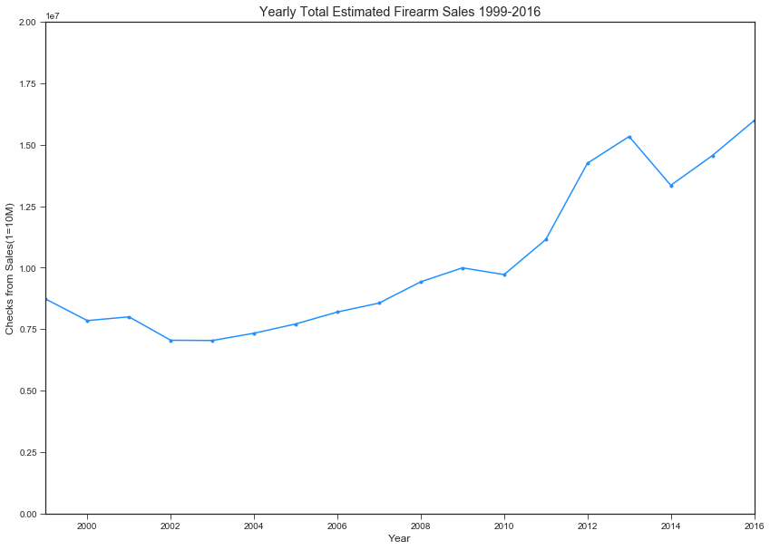

```python
yearly_sales_est['total_est_sales'].plot(kind='line', figsize=(14,10), marker='.',color='dodgerblue')
plt.title('Yearly Total Estimated Firearm Sales 1999-2016')
plt.xlim(1999,2016)
plt.ylim(0,20000000)
plt.ylabel('Checks from Sales(1=10M)')
plt.xlabel('Year')
plt.show()
```

#### Yearly Sales Trends

> Looking at the graph above, it looks like the amount of guns purchased decreased from 1999 until about 2002 where it began to steadily increase until 2009, then spiked from 2010 to 2013. The leveling and increase from 2002 on (after a previous decrease before 2002) is interesting to note because many articles came out after the September 11 attacks in 2001 about increases in guns sales. It is impossible to establish a correlation between 9/11 and gun sales from the data we have here, but we can at least see a clear change in direction of sales at the 2002 mark which has led us to ask more questions. Even if we can't establish this correlation, we have other data that might explain the overall increase in the gun sales we have estimated from 1999 to 2016. Throughout this analysis, we must still keep in mind that using background checks to estimate gun sales levels is not supported by a one-to-one correlation between a check and a sale. Regardless, the background check numbers are real data, and can help us to make inferences about the interactions between people and the guns they aquire by a legal process.

### 2) Comparing Gun Sales by State

Next, to get a picture of the distribution of gun sales across the U.S., it will be necessary to take a look at estimated firearm sales at the state level. It will be interesting to see which states have higher and lower sales. We will look specifically at 2010 and 2016 sales so that later we can compare our results with the Census data, which has data that varies between being collected in 2010 and 2016.

> Which 5 states have the highest levels of estimated gun sales? Which 5 states are at the bottom of the list of estimated gun sales? Are the top 5 in 2016 consistent with the top 5 in 2010?...are the bottom 5 similarly consistent?

#### State Gun Sales

Below, we have a function, **state_year_totals()**, that returns a dictionary containing the level of estimated gun sales for each of the 50 states for each year from a list of years. We will use this function to generate values for a new pandas DataFrame.

```python
def state_year_totals(df, column_name, state, years):
    """This function returns a dictionary containing state yearly totals
       for a given column of a specified DataFrame"""
    st_yearly_totals = {}
    state_df = df.loc[state, ['year', column_name]]
    for year in years:
        st_yearly_totals[year] = sum(state_df.loc[state_df['year'] == year, column_name])
    return st_yearly_totals
```

Next, we need a list of state names to use as indices for the new DataFrame with state totals.

```python
#state list for indexing a new DataFrame
state_list = []
for item in clean_census_data.index:
    state_list.append(item)
```

Now, we can create lists for the columns of the new DataFrame using the **state_year_totals()** function and **state_list**...

```python
year_list=[2010,2016]
stately_twentyten = []
stately_twentysixteen = []
for state in state_list:
    stately_twentyten.append(state_year_totals(clean_check_data, 'sales_checks', state, year_list)[2010])
    stately_twentysixteen.append(state_year_totals(clean_check_data, 'sales_checks', state, year_list)[2016])
```

...and create a new DataFrame, **state_yearly_df**, with an extra column with the percent change between 2010 and 2016 sales estimates to be used later (for comparison with Census data).

```python
state_yearly_df = pd.DataFrame({'state':state_list,
                                '2010 sales est':stately_twentyten,
                                '2016 sales est':stately_twentysixteen})
state_yearly_df = state_yearly_df.set_index('state')
state_yearly_df['Percent Change sales est'] = [(((state_yearly_df.loc[state]['2016 sales est'] - state_yearly_df.loc[state]['2010 sales est'])/state_yearly_df.loc[state]['2010 sales est'])*100) for state in state_list]
state_yearly_df
```

| state | 2010 sales est | 2016 sales est | Percent Change sales est |
| --- | --- | --- | --- |
| Alabama | 289760.2 | 315684.6 | 8.946846 |
| Alaska | 67824.7 | 86447.8 | 27.457696 |
| Arizona | 181587.9 | 319165.2 | 75.763473 |
| Arkansas | 140707.8 | 187400.4 | 33.184088 |
| California | 572678.7 | 1226395.5 | 114.150710 |
| Colorado | 341964.7 | 493366.8 | 44.274190 |
| Connecticut | 96900.1 | 182806.8 | 88.654914 |
| Delaware | 21239.6 | 54120.0 | 154.807059 |
| Florida | 602032.6 | 1126678.0 | 87.145679 |
| Georgia | 222710.6 | 370340.7 | 66.287864 |
| Hawaii | 0.0 | 0.0 | NaN |
| Idaho | 74506.5 | 117137.4 | 57.217692 |
| Illinois | 259845.0 | 606898.6 | 133.561777 |
| Indiana | 258061.5 | 519104.0 | 101.155151 |
| Iowa | 45178.8 | 41988.4 | -7.061719 |
| Kansas | 144463.0 | 178892.4 | 23.832677 |
| Kentucky | 214429.1 | 288612.1 | 34.595584 |
| Louisiana | 237827.6 | 358999.0 | 50.949259 |
| Maine | 70064.8 | 110103.5 | 57.145243 |
| Maryland | 94317.5 | 137290.7 | 45.562276 |
| Massachusetts | 62984.1 | 134658.8 | 113.798086 |
| Michigan | 163472.1 | 328993.7 | 101.253731 |
| Minnesota | 198226.7 | 315347.5 | 59.084271 |
| Mississippi | 150795.3 | 243585.2 | 61.533682 |
| Missouri | 334050.0 | 550714.2 | 64.859811 |
| Montana | 84824.6 | 109175.1 | 28.706885 |
| Nebraska | 32031.8 | 31196.1 | -2.608970 |
| Nevada | 97804.8 | 122135.3 | 24.876591 |
| New Hampshire | 62572.8 | 124641.0 | 99.193579 |
| New Jersey | 56363.5 | 131282.8 | 132.921660 |
| New Mexico | 98174.1 | 145071.8 | 47.769931 |
| New York | 229943.7 | 368982.5 | 60.466453 |
| North Carolina | 148774.6 | 218489.4 | 46.859343 |
| North Dakota | 45210.6 | 61330.8 | 35.655798 |
| Ohio | 410231.0 | 735052.3 | 79.180096 |
| Oklahoma | 218105.7 | 347686.5 | 59.411927 |
| Oregon | 208192.9 | 353919.5 | 69.995951 |
| Pennsylvania | 688071.4 | 880410.3 | 27.953334 |
| Rhode Island | 16909.3 | 30910.6 | 82.802363 |
| South Carolina | 149382.2 | 250854.6 | 67.928040 |
| South Dakota | 65851.7 | 99014.2 | 50.359368 |
| Tennessee | 344674.8 | 604447.0 | 75.367332 |
| Texas | 812262.5 | 1297197.5 | 59.701759 |
| Utah | 80198.7 | 114069.4 | 42.233478 |
| Vermont | 26822.6 | 42660.3 | 59.046103 |
| Virginia | 357882.4 | 556531.8 | 55.506893 |
| Washington | 252276.4 | 417704.5 | 65.574148 |
| West Virginia | 140766.7 | 201117.9 | 42.873208 |
| Wisconsin | 208906.0 | 381738.4 | 82.732138 |
| Wyoming | 41320.9 | 55812.4 | 35.070630 |

We can now plot a bar graph to take a look at the state levels of estimated gun sales. (Note: Hawaii doesn't have data for these years, we will ignore it moving on and delete the row if necessary later.)

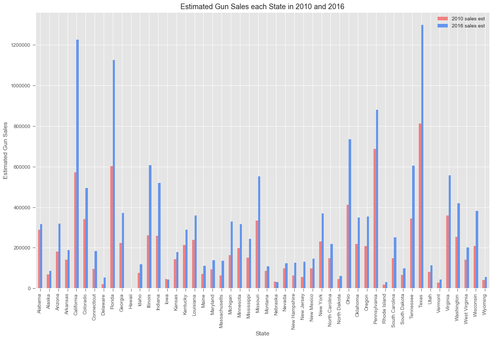

```python
plt.style.use('ggplot')
state_yearly_df[['2010 sales est', '2016 sales est']].plot(kind='bar', figsize=(16,10), color = ['lightcoral','cornflowerblue'])
plt.title('Estimated Gun Sales each State in 2010 and 2016')
plt.ylabel('Estimated Gun Sales')
plt.xlabel('State')
plt.show()
```

### 3) Gun Sales and Population (and Population Density)

So far, we have seen an overall increase in U.S. gun sales based on our estimates and have even seen a greater increase in recent years (2010-2016). We also know which states have the highest and lowest levels of estimated sales in 2010 and 2016. In the Census data, we have population estimates in both 2010 and 2016 for all 50 states. It will be interesting now to figure out whether the levels of guns in each state follow the levels of population in each state.

> How does the number of guns sold in a state compare to the population of that state (people per single gun)? Does the population size of a given region tell us anything about total estimated gun sales in that region?

#### Population and Gun Sales in 2010 and 2016

We'll start by creating a DataFrame that will have both the sales and population estimates from 2010 and 2016, as well as the percent changes for both. Then, we can compare levels of sales and population in both years as well as changes in levels between both years. We have the population and sales estimate levels in previously created DataFrames, so we will only need to calculate the percent change in population estimates between 2010 and 2016 to combine into a new DataFrame.

```python
#list creation with population percent changes for each state from index of census DataFrame
state_population_change = []
for state in clean_census_data.index:
    state_population_change.append((((clean_census_data['Population Estimate 2016'][state])-(clean_census_data['Population Estimate 2010'][state]))/(clean_census_data['Population Estimate 2010'][state]))*100)
```

Now, we can use the above percent change list and combine it with previously made DataFrame columns to modify the **state_yearly_df** DataFrame. We will add columns for ratio of sales to population for 2010 and 2016 estimates, as well as and percent changes; also, a column each for 2010 and 2016 to describe the number of people per gun sold. Now is a good time to delete Hawaii from the DataFrame in order to get more accurate statistics.

```python
state_yearly_df['Population 2010 est'] = clean_census_data['Population Estimate 2010']
state_yearly_df['Population 2016 est'] = clean_census_data['Population Estimate 2016']
state_yearly_df['Percent Change Population est'] = state_population_change
#computing ratio of sales to population same as guns per person
state_yearly_df['Ratio of Sales to Population 2010'] = (state_yearly_df['2010 sales est'])/(state_yearly_df['Population 2010 est'])
state_yearly_df['Ratio of Sales to Population 2016'] = (state_yearly_df['2016 sales est'])/(state_yearly_df['Population 2016 est'])
#divide 1 by ratio of sales to pop.(guns per person) results in people per gun.
state_yearly_df['People per Gun 2010'] = 1/state_yearly_df['Ratio of Sales to Population 2010']
state_yearly_df['People per Gun 2016'] = 1/state_yearly_df['Ratio of Sales to Population 2016']
state_yearly_df = state_yearly_df.drop('Hawaii')
state_yearly_df
```

| state | 2010 sales est | 2016 sales est | Percent Change sales est | Population 2010 est | Population 2016 est | Percent Change Population est | Ratio of Sales to Population 2010 | Ratio of Sales to Population 2016 | People per Gun 2010 | People per Gun 2016 |
| --- | --- | --- | --- | --- | --- | --- | --- | --- | --- | --- |
| Alabama | 289760.2 | 315684.6 | 8.946846 | 4780131 | 4863300 | 1.739890 | 0.060618 | 0.064912 | 16.496852 | 15.405566 |
| Alaska | 67824.7 | 86447.8 | 27.457696 | 710249 | 741894 | 4.455480 | 0.095494 | 0.116523 | 10.471834 | 8.581988 |
| Arizona | 181587.9 | 319165.2 | 75.763473 | 6392301 | 6931071 | 8.428420 | 0.028407 | 0.046048 | 35.202241 | 21.716249 |
| Arkansas | 140707.8 | 187400.4 | 33.184088 | 2916025 | 2988248 | 2.476762 | 0.048253 | 0.062712 | 20.723976 | 15.945793 |
| California | 572678.7 | 1226395.5 | 114.150710 | 37254522 | 39250017 | 5.356383 | 0.015372 | 0.031246 | 65.053095 | 32.004371 |
| Colorado | 341964.7 | 493366.8 | 44.274190 | 5029324 | 5540545 | 10.164805 | 0.067994 | 0.089047 | 14.707144 | 11.230073 |
| Connecticut | 96900.1 | 182806.8 | 88.654914 | 3574114 | 3576452 | 0.065415 | 0.027112 | 0.051114 | 36.884523 | 19.564108 |
| Delaware | 21239.6 | 54120.0 | 154.807059 | 897936 | 952065 | 6.028158 | 0.023654 | 0.056845 | 42.276502 | 17.591741 |
| Florida | 602032.6 | 1126678.0 | 87.145679 | 18804592 | 20612439 | 9.613859 | 0.032015 | 0.054660 | 31.235172 | 18.294880 |
| Georgia | 222710.6 | 370340.7 | 66.287864 | 9688680 | 10310371 | 6.416674 | 0.022987 | 0.035919 | 43.503452 | 27.840232 |
| Idaho | 74506.5 | 117137.4 | 57.217692 | 1567650 | 1683140 | 7.367078 | 0.047528 | 0.069595 | 21.040446 | 14.368938 |
| Illinois | 259845.0 | 606898.6 | 133.561777 | 12831574 | 12801539 | -0.234071 | 0.020250 | 0.047408 | 49.381647 | 21.093374 |
| Indiana | 258061.5 | 519104.0 | 101.155151 | 6484136 | 6633053 | 2.296636 | 0.039799 | 0.078260 | 25.126321 | 12.777888 |
| Iowa | 45178.8 | 41988.4 | -7.061719 | 3046869 | 3134693 | 2.882434 | 0.014828 | 0.013395 | 67.440237 | 74.656167 |
| Kansas | 144463.0 | 178892.4 | 23.832677 | 2853129 | 2907289 | 1.898267 | 0.050633 | 0.061532 | 19.749894 | 16.251607 |
| Kentucky | 214429.1 | 288612.1 | 34.595584 | 4339344 | 4436974 | 2.249879 | 0.049415 | 0.065047 | 20.236731 | 15.373486 |
| Louisiana | 237827.6 | 358999.0 | 50.949259 | 4533479 | 4681666 | 3.268726 | 0.052460 | 0.076682 | 19.062039 | 13.040889 |
| Maine | 70064.8 | 110103.5 | 57.145243 | 1328364 | 1331479 | 0.234499 | 0.052745 | 0.082693 | 18.959078 | 12.092976 |
| Maryland | 94317.5 | 137290.7 | 45.562276 | 5773786 | 6016447 | 4.202806 | 0.016335 | 0.022819 | 61.216487 | 43.822684 |
| Massachusetts | 62984.1 | 134658.8 | 113.798086 | 6547813 | 6811779 | 4.031361 | 0.009619 | 0.019769 | 103.959777 | 50.585472 |
| Michigan | 163472.1 | 328993.7 | 101.253731 | 9884129 | 9928300 | 0.446888 | 0.016539 | 0.033137 | 60.463706 | 30.177782 |
| Minnesota | 198226.7 | 315347.5 | 59.084271 | 5303924 | 5519952 | 4.072984 | 0.037374 | 0.057129 | 26.756860 | 17.504347 |
| Mississippi | 150795.3 | 243585.2 | 61.533682 | 2968103 | 2988726 | 0.694821 | 0.050805 | 0.081501 | 19.682994 | 12.269736 |
| Missouri | 334050.0 | 550714.2 | 64.859811 | 5988928 | 6093000 | 1.737740 | 0.055778 | 0.090385 | 17.928238 | 11.063815 |
| Montana | 84824.6 | 109175.1 | 28.706885 | 989414 | 1042520 | 5.367420 | 0.085732 | 0.104722 | 11.664234 | 9.549064 |
| Nebraska | 32031.8 | 31196.1 | -2.608970 | 1826334 | 1907116 | 4.423178 | 0.017539 | 0.016358 | 57.016278 | 61.133154 |
| Nevada | 97804.8 | 122135.3 | 24.876591 | 2700691 | 2940058 | 8.863176 | 0.036215 | 0.041542 | 27.613072 | 24.072140 |
| New Hampshire | 62572.8 | 124641.0 | 99.193579 | 1316461 | 1334795 | 1.392673 | 0.047531 | 0.093378 | 21.038870 | 10.709117 |
| New Jersey | 56363.5 | 131282.8 | 132.921660 | 8791953 | 8944469 | 1.734723 | 0.006411 | 0.014678 | 155.986640 | 68.131309 |
| New Mexico | 98174.1 | 145071.8 | 47.769931 | 2059198 | 2081015 | 1.059490 | 0.047676 | 0.069712 | 20.974962 | 14.344724 |
| New York | 229943.7 | 368982.5 | 60.466453 | 19378110 | 19745289 | 1.894813 | 0.011866 | 0.018687 | 84.273281 | 53.512806 |
| North Carolina | 148774.6 | 218489.4 | 46.859343 | 9535688 | 10146788 | 6.408557 | 0.015602 | 0.021533 | 64.094866 | 46.440642 |
| North Dakota | 45210.6 | 61330.8 | 35.655798 | 672591 | 757952 | 12.691368 | 0.067219 | 0.080916 | 14.876843 | 12.358424 |
| Ohio | 410231.0 | 735052.3 | 79.180096 | 11536727 | 11614373 | 0.673033 | 0.035559 | 0.063288 | 28.122514 | 15.800744 |
| Oklahoma | 218105.7 | 347686.5 | 59.411927 | 3751615 | 3923561 | 4.583253 | 0.058136 | 0.088615 | 17.200903 | 11.284767 |
| Oregon | 208192.9 | 353919.5 | 69.995951 | 3831072 | 4093465 | 6.849075 | 0.054343 | 0.086460 | 18.401550 | 11.566091 |
| Pennsylvania | 688071.4 | 880410.3 | 27.953334 | 12702857 | 12784227 | 0.640565 | 0.054167 | 0.068867 | 18.461539 | 14.520760 |
| Rhode Island | 16909.3 | 30910.6 | 82.802363 | 1052940 | 1056426 | 0.331073 | 0.016059 | 0.029260 | 62.269875 | 34.176820 |
| South Carolina | 149382.2 | 250854.6 | 67.928040 | 4625410 | 4961119 | 7.257930 | 0.032296 | 0.050564 | 30.963595 | 19.776871 |
| South Dakota | 65851.7 | 99014.2 | 50.359368 | 814195 | 865454 | 6.295666 | 0.080880 | 0.114407 | 12.364070 | 8.740706 |
| Tennessee | 344674.8 | 604447.0 | 75.367332 | 6346298 | 6651194 | 4.804313 | 0.054311 | 0.090878 | 18.412422 | 11.003767 |
| Texas | 812262.5 | 1297197.5 | 59.701759 | 25146100 | 27862596 | 10.802852 | 0.032302 | 0.046557 | 30.958095 | 21.479070 |
| Utah | 80198.7 | 114069.4 | 42.233478 | 2763888 | 3051217 | 10.395826 | 0.029017 | 0.037385 | 34.463003 | 26.748777 |
| Vermont | 26822.6 | 42660.3 | 59.046103 | 625741 | 624594 | -0.183303 | 0.042865 | 0.068301 | 23.328872 | 14.641107 |
| Virginia | 357882.4 | 556531.8 | 55.506893 | 8001041 | 8411808 | 5.133919 | 0.044729 | 0.066161 | 22.356620 | 15.114694 |
| Washington | 252276.4 | 417704.5 | 65.574148 | 6724545 | 7288000 | 8.379080 | 0.037516 | 0.057314 | 26.655466 | 17.447741 |
| West Virginia | 140766.7 | 201117.9 | 42.873208 | 1853011 | 1831102 | -1.182346 | 0.075966 | 0.109834 | 13.163703 | 9.104620 |
| Wisconsin | 208906.0 | 381738.4 | 82.732138 | 5687289 | 5778708 | 1.607427 | 0.036732 | 0.066059 | 27.224153 | 15.137875 |
| Wyoming | 41320.9 | 55812.4 | 35.070630 | 563767 | 585501 | 3.855139 | 0.073294 | 0.095324 | 13.643628 | 10.490518 |

Now we can take a closer look at the data...

```python
pl.hist()
```

[output not shown]

```python
#2010 summary: People per single gun sold
state_yearly_df['People per Gun 2010'].describe()
```

```
count     49.000000
mean      34.756904
std       27.168585
min       10.471834
25%       18.461539
50%       25.126321
75%       42.276502
max      155.986640
Name: People per Gun 2010, dtype: float64
```

**2010**: In New Jersey, the maximum of the data, there were about 156 people for every gun sold (according to the estimates). The same year in Alaska, the minimum, there were about 10 people for every gun. This is likely because New Jersey had a bigger population (in 2010, about 9 million) in a smaller area, while Alaska had a much smaller population (2010: 710,249) in a larger area. Overall (in the U.S. excluding Hawaii), on average, one gun was bought for every 35th person, according to the Census numbers and our sales estimate.

```python
#2016 summary: People per single gun sold
state_yearly_df['People per Gun 2016'].describe()
```

```
count    49.000000
mean     22.255928
std      15.982036
min       8.581988
25%      12.269736
50%      15.800744
75%      24.072140
max      74.656167
Name: People per Gun 2016, dtype: float64
```

**2016**: In Iowa, there were about 75 people for every gun sold. Iowa was the maximum of the data for 2016, but not 2010. Looking in the percent change columns, we can see that this increase in people per single gun sold is explained by a 7% decrease in sales while population increased by about 3%. The minimum of 2016 was again Alaska, with about 9 people per single gun sold. Looking at the data, it appears that population may have increased from 2010 to 2016 in Alaska (+4.5%), but not enough to offset a comparatively greater increase in sales estimates (+27.5%) from 2010 to 2016, bringing the popularity of guns up (less people per single gun). Overall (in the U.S. excluding Hawaii), on average, one gun was bought for every 22nd person, according to the Census numbers and our sales estimate. So, to confirm and extend what we found earlier about gun sales trends going up from 2010 to 2016, sales have gone up, but not just because of population increases; gun popularity itself--the percentage of the population purchasing guns--has grown (assuming our estimates are accurate).

#### Population per Gun versus per Square Mile in 2010

Above, when discussing a couple of examples of population per single gun, we noticed that the places with the lowest gun popularity (more people per single gun--> New Jersey in 2010 and Iowa in 2016) were drastically different from places with the highest gun popularity (Alaska in both years) in that they had higher populations per unit of area. Since we have population per square mile data for 2010 in the Census data, we can explore this data to come to some conclusions about the relationship between people and gun sales. To begin, below we will drop Hawaii from the Census data as we have for the sales and population data.

```python
clean_census_data = clean_census_data.drop(['Hawaii'])
```

Now, we can plot population per square mile and people per gun for 2010 and get a rough look at the relative difference between the statistics across the 49 states in the dataset.

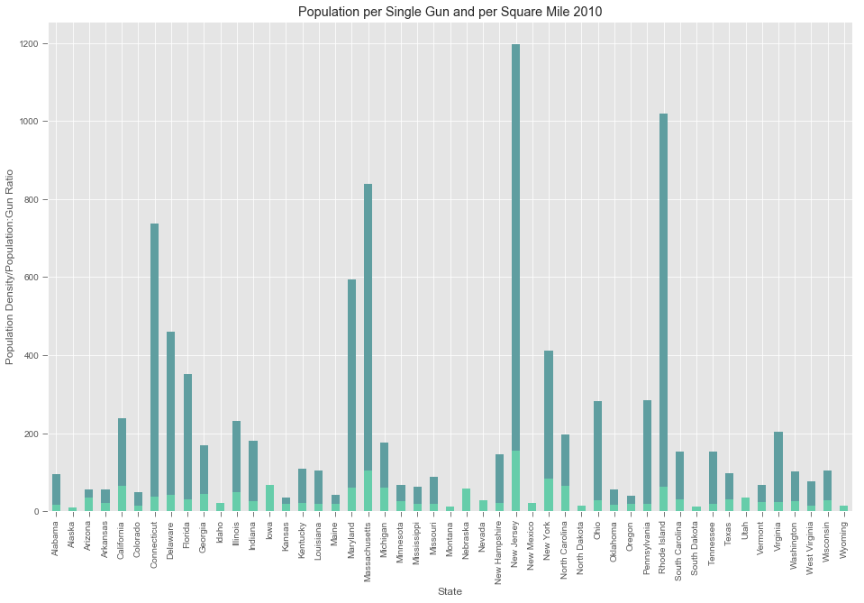

```python
plt.style.use('ggplot')
clean_census_data['Population per Square Mile'].plot(kind='bar', figsize=(16,10), color = ['cadetblue'])
state_yearly_df['People per Gun 2010'].plot(kind='bar', figsize=(16,10), color = ['mediumaquamarine'])
plt.title('Population per Single Gun and per Square Mile 2010')
plt.ylabel('Population Density/Population:Gun Ratio')
plt.xlabel('State')
plt.show()
```

Generally, we can see that many of the states above with high population densities (shown in dark green/blue) have higher population to gun ratios (shown in lighter green/blue), or lower gun popularity, relative to other state levels. For the lowest people-per-gun states (high gun popularity states) on this graph (Alaska, Idaho, Montana, New Mexico, etc.), population per square mile isn't even visible, but this makes sense taken with our previous statement, as these lowest levels are also met with the lowest people-per-gun ratios. If we scatter plot population per square mile and the population-to-gun ratio for each of these states, we can see a moderate positive association. We can see this below, but we have to keep in mind that we only have 49 data points, and this isn't enough to prove definitively that these two statistics are positively correlated.

[figure not shown]

```python
sb.set_style('ticks')
fig, ax = plt.subplots()
fig.set_size_inches(18, 11)
sb.regplot(clean_census_data['Population per Square Mile'], state_yearly_df['People per Gun 2010'], ax=ax, color='dodgerblue')

plt.title('Population per Gun vs. Population per Square Mile')
plt.ylabel('Population Per Square Mile')
plt.xlabel('People per Single Gun')
plt.show()
```

#### Guns and Population Density

Given that the we are using estimations of gun sales, our conclusions this far cannot be 100% accurate. However, given the data we have, we can begin to make the case that not only have gun numbers increased in over the past decade, but also that gun popularity has increased due to a decreasing average proportion of people to guns sold across the United States. There may be also a relationship between gun popularity and population density, as many states in our data set that are more urban (dense population) have lower gun popularity (people per gun), while many rural states (sparse population) have higher gun popularity. These results may make sense for 2010, but to establish that these conclusions are true in general, we would need Census and background check data for many more years.

### Research Limitations

Throughout this analysis, there were many limitations that could have led to less than accurate results:

> 1) Background Checks are not correlated 1-to-1 with gun sales; meaning that we cannot definitively say that gun sales are going up when background check levels are going up. Therefore, the background check data is not sufficient to prove our results; we would need data on actual sales to do so.

> 2)Furthermore, the data was not 100% complete; for example, we ommitted Hawaii at one point in the analysis because it lacked data. We then computed averages to summarize the U.S. when there was actually a state missing (1 state could provide enough data to change results significantly in a set of 50 states).

> 3) State laws differ from state to state, and some states have different ways of measuring data. So, when we compared state levels, many of the results attributed to one variable (such as population density) could have instead been the results of differences in state laws.

## Conclusions

In this analysis, we have learned quite a bit about guns in the United States in recent history, even if we are using backgroud checks as a proxy for sales.

> 1) The amount of guns purchased have probably increased year to year (if background checks somewhat accurately estimate the numbers, they surely are).

> 2) Increases in population may not be the sole cause of the fact that more people are buying guns as time goes on, as an increasing percentage of the population has been getting background checked (buying guns) in recent years.

> 3) Guns may be more popular in rural regions and less popular in urban regions (although state laws might have something to do with this).

```python
from subprocess import call
call(['python', '-m', 'nbconvert', 'Investigate_a_Datasettt.ipynb'])
```

```
0
```